# My Third Sweet R Markdown Notebook

Jason Edelkind

2023-09-13

# Introduction

My study species is the gila monster

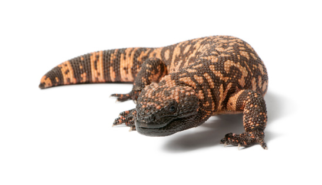

Figure 1. *Heloderma suspectum*

[figure not shown]

Figure 2. *Heloderma suspectum* Habitat

# Map of Study Sites

First I’ll make a map of the project study sites

[interactive chart not shown]

# Examining the Data

My dataset consists of annual [Gila Monster](https://www.iucnredlist.org/species/9865/13022716) home range estimates and a variety of environmental variables quantifying different aspects of precipitation, temperature, and vegetation productivity.

Time to examine the data

Table 1. A knitr kable displaying the first 15 Individual-Year combination home range estimates in the data set.

| Year | ID | Site | Sex | MCP | KDE | AKDE | WAKDE |
| --- | --- | --- | --- | --- | --- | --- | --- |
| 2016 | CB03 | CB | Unk | 10.972918 | 23.609285 | 25.833175 | 24.589618 |
| 2017 | CB03 | CB | Unk | 6.115960 | 9.444815 | 9.947334 | 9.162764 |
| 2018 | CB03 | CB | Unk | 11.897122 | 36.466389 | 39.198394 | 36.249172 |
| 2019 | CB03 | CB | Unk | 32.923651 | 57.713717 | 57.713717 | 57.713717 |
| 2020 | CB03 | CB | Unk | 12.177214 | 19.641703 | 23.253088 | 21.450123 |
| 2021 | CB03 | CB | Unk | 17.372201 | 26.958363 | 36.297575 | 33.516153 |
| 2016 | CB04 | CB | Unk | 24.895519 | 51.609680 | 52.857987 | 48.609173 |
| 2017 | CB04 | CB | Unk | 31.550017 | 58.776878 | 104.695330 | 92.016309 |
| 2018 | CB04 | CB | Unk | 13.125271 | 22.831668 | 22.831668 | 22.831668 |
| 2019 | CB04 | CB | Unk | 8.019974 | 17.694837 | 18.879281 | 18.120550 |
| 2020 | CB04 | CB | Unk | 11.409831 | 24.078995 | 36.660380 | 35.799982 |
| 2017 | CB06 | CB | Unk | 36.895534 | 73.829120 | 93.997406 | 93.769550 |
| 2018 | CB06 | CB | Unk | 20.320797 | 27.158028 | 43.850106 | 39.357647 |
| 2017 | CB07 | CB | Unk | 9.842281 | 22.881558 | 23.396750 | 22.201632 |
| 2018 | CB07 | CB | Unk | 10.415638 | 27.248699 | 27.248699 | 27.248699 |

We have data from 162 annual home ranges. The average home range size is 88.58 hectares. Home range size varies from 0.09 to 864.68 hectares.

# Home Range Summary by Site

Table 2. A summary kable displaying mean WAKDE home range size, sample size, and standard error of each study site

| Site | meanWAKDE | n | se_WAKDE |
| --- | --- | --- | --- |
| CB | 75.50567 | 43 | 17.437596 |
| MC | 79.18073 | 13 | 14.420606 |
| PX | 91.52446 | 18 | 25.757401 |
| SC | 24.51457 | 27 | 2.269185 |
| SG | 470.36168 | 1 | NA |
| SZ | 57.27713 | 9 | 9.553954 |
| TM | 36.97165 | 16 | 6.239739 |
| VF | 176.77080 | 35 | 32.543173 |

# Comparing Home Range Size by Site

Next I’ll create a barplot of average annual home range size at each site

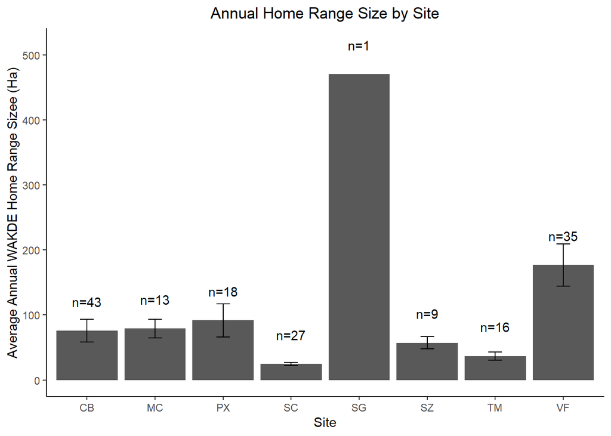

# Effect of Vegetative Productivity on Annual Home Range Size

Now I’ll create and analyze a linear model testing for the effect of vegetative productivity, measured by average annual [MSAVI2](https://www.usgs.gov/landsat-missions/landsat-modified-soil-adjusted-vegetation-index), on annual WAKDE home range size

```r
#creating a linear model of WAKDE home range size and MSAVI2
model_1 <- lm(WAKDE ~ Avg.MSAVI2, data = Env.HR)
anova(model_1)
```

|  | Df | Sum Sq | Mean Sq | F value | Pr(>F) |
| --- | --- | --- | --- | --- | --- |
| Avg.MSAVI2 | 1 | 93993.94 | 93993.94 | 5.876225 | 0.0164611 |
| Residuals | 160 | 2559301.37 | 15995.63 | NA | NA |

Now I’ll plot the MSAVI2 values and the home range estimates

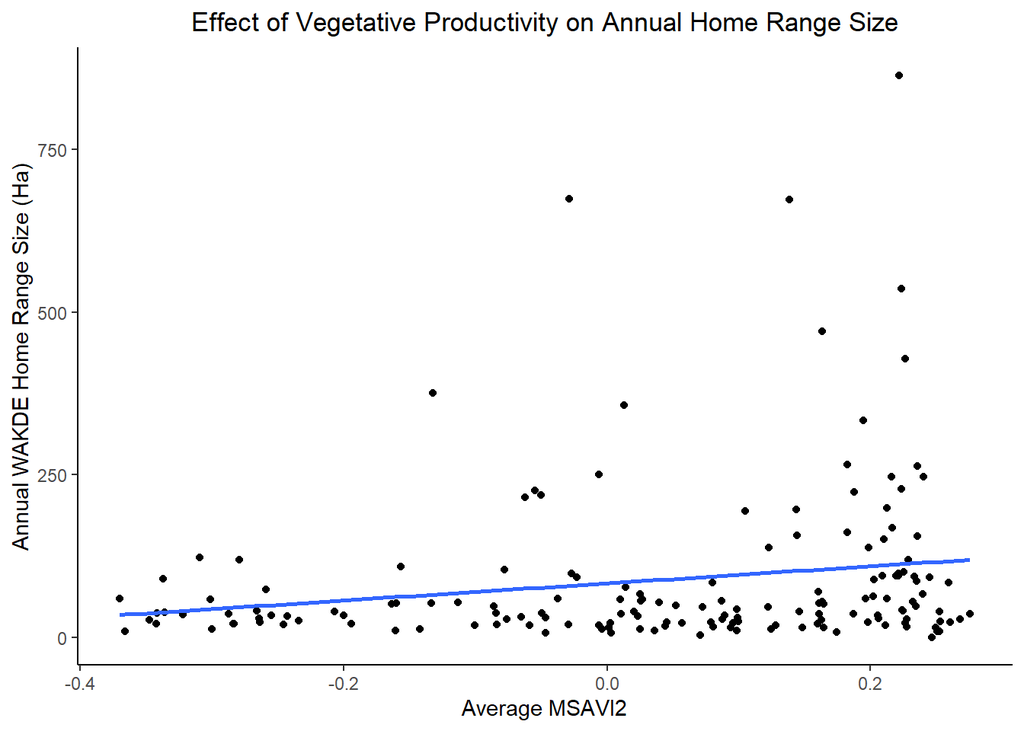

# Effect of Active Season Precipitation on Home Range Size

Now I’ll create and analyze a linear model testing for the effect of active season precipitation on annual WAKDE home range size

```r
#creating a linear model of WAKDE home range size and active season precipitation
model_2 <- lm(WAKDE ~ Avg.AS.Precip, data = Env.HR)
anova(model_2)
```

|  | Df | Sum Sq | Mean Sq | F value | Pr(>F) |
| --- | --- | --- | --- | --- | --- |
| Avg.AS.Precip | 1 | 306798.8 | 306798.8 | 20.91962 | 9.547283e-06 |
| Residuals | 160 | 2346496.5 | 14665.6 | NA | NA |

Next I’ll create a point plot comparing average active season (March-August) precipitation and annual home range size

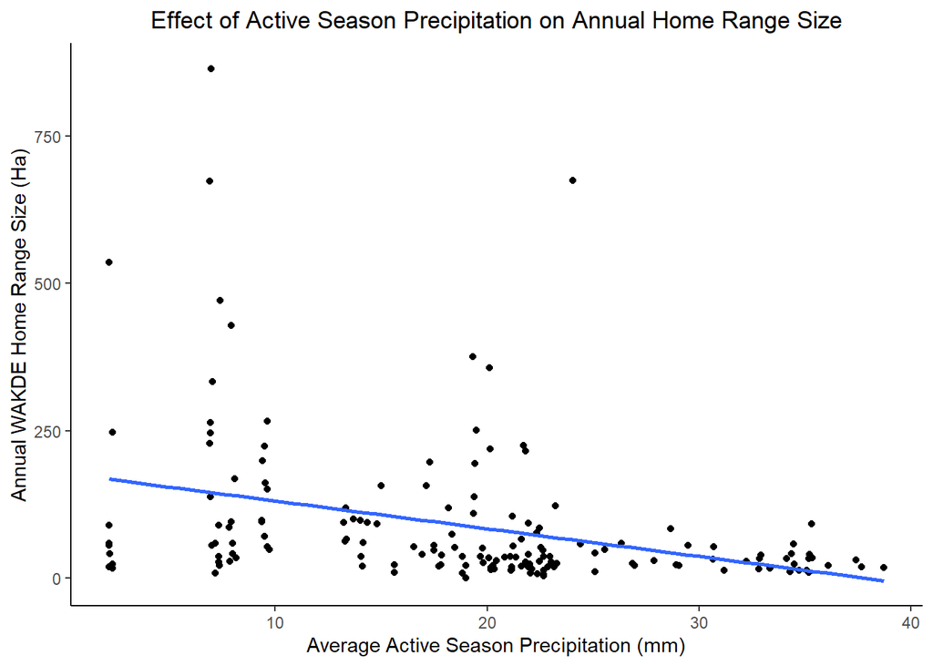

# Angry Gila Monster

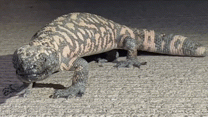

# Gila Monster Video

[video not shown]

# Gila Monster Shreds Radly

[figure not shown]